# 第5章：探索的データ解析（Ⅱ）

## 5.1 エリアごとに性別・年代の円グラフを作成してみよう。エリアごとに違いはあるだろうか？

### 【解答例1】

#### エリアごとの性別の円グラフ

```python
import numpy as np
import pandas as pd
import matplotlib.pyplot as plt
%matplotlib inline

df1 = pd.read_csv("../input/gi_train_mm10.csv") # 10月のデータ
df2 = pd.read_csv("../input/gi_train_mm11.csv") # 11月のデータ

df_tmp = pd.concat([df1, df2])
df = df_tmp[df_tmp["customer_id"].notna()].copy()
df_et1 = df.loc[(df["event_type"] == 1)]
df_et2 = df.loc[(df["event_type"] == 2)]
df_et2["area_id"] = df_et2["area_id"].astype(int).astype(str)
```

```python
df_customer_attribute = \
    df_et2[["customer_id", "gender", "age", "age_category", "area_id"]].drop_duplicates()
```

```python
df_customer_attribute_ai1 = df_customer_attribute.loc[(df_customer_attribute["area_id"] == "1")]
df_customer_attribute_ai2 = df_customer_attribute.loc[(df_customer_attribute["area_id"] == "2")]
df_customer_attribute_ai3 = df_customer_attribute.loc[(df_customer_attribute["area_id"] == "3")]
df_customer_attribute_ai4 = df_customer_attribute.loc[(df_customer_attribute["area_id"] == "4")]
df_customer_attribute_ai5 = df_customer_attribute.loc[(df_customer_attribute["area_id"] == "5")]
```

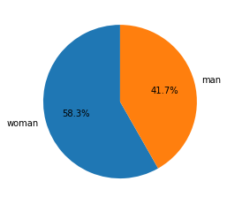

```
woman    1232
man       883
Name: gender, dtype: int64
```

```python
gender_counts = df_customer_attribute_ai1["gender"].value_counts()
plt.pie(\
    gender_counts, labels=gender_counts.index, autopct="%.1f%%", startangle=90)
plt.show()
print(gender_counts)
```

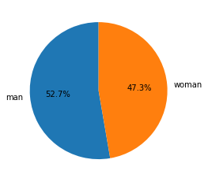

```
man      547
woman    491
Name: gender, dtype: int64
```

```python
gender_counts = df_customer_attribute_ai2["gender"].value_counts()
plt.pie(\
    gender_counts, labels=gender_counts.index, autopct="%.1f%%", startangle=90)
plt.show()
print(gender_counts)
```

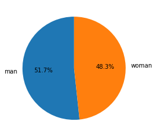

```
man      879
woman    821
Name: gender, dtype: int64
```

```python
gender_counts = df_customer_attribute_ai3["gender"].value_counts()
plt.pie(\
    gender_counts, labels=gender_counts.index, autopct="%.1f%%", startangle=90)
plt.show()
print(gender_counts)
```

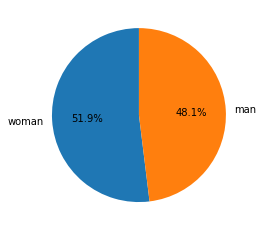

```
woman    387
man      358
Name: gender, dtype: int64
```

```python
gender_counts = df_customer_attribute_ai4["gender"].value_counts()
plt.pie(\
    gender_counts, labels=gender_counts.index, autopct="%.1f%%", startangle=90)
plt.show()
print(gender_counts)
```

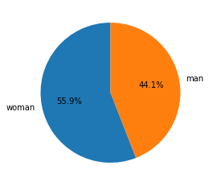

```
woman    608
man      479
Name: gender, dtype: int64
```

```python
gender_counts = df_customer_attribute_ai5["gender"].value_counts()
plt.pie(\
    gender_counts, labels=gender_counts.index, autopct="%.1f%%", startangle=90)
plt.show()
print(gender_counts)
```

#### エリアごとの年代の円グラフ

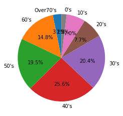

```
Over70's     67
60's        312
50's        412
40's        541
30's        432
20's        162
10's        148
0's          41
Name: age, dtype: int64
```

```python
age_counts = \
    df_customer_attribute_ai1["age"].value_counts().sort_index(ascending=False)
plt.pie(age_counts, labels=age_counts.index, autopct="%.1f%%", startangle=90)
plt.show()
print(age_counts)
```

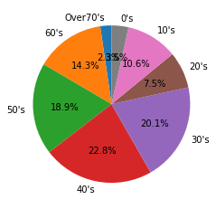

```
Over70's     24
60's        148
50's        196
40's        237
30's        209
20's         78
10's        110
0's          36
Name: age, dtype: int64
```

```python
age_counts = \
    df_customer_attribute_ai2["age"].value_counts().sort_index(ascending=False)
plt.pie(age_counts, labels=age_counts.index, autopct="%.1f%%", startangle=90)
plt.show()
print(age_counts)
```

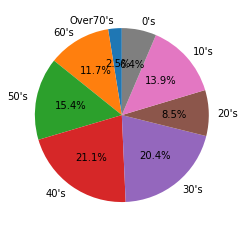

```
Over70's     43
60's        199
50's        261
40's        359
30's        347
20's        145
10's        237
0's         109
Name: age, dtype: int64
```

```python
age_counts = \
    df_customer_attribute_ai3["age"].value_counts().sort_index(ascending=False)
plt.pie(age_counts, labels=age_counts.index, autopct="%.1f%%", startangle=90)
plt.show()
print(age_counts)
```

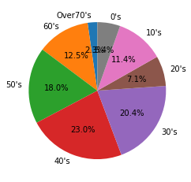

```
Over70's     17
60's         93
50's        134
40's        171
30's        152
20's         53
10's         85
0's          40
Name: age, dtype: int64
```

```python
age_counts = \
    df_customer_attribute_ai4["age"].value_counts().sort_index(ascending=False)
plt.pie(age_counts, labels=age_counts.index, autopct="%.1f%%", startangle=90)
plt.show()
print(age_counts)
```

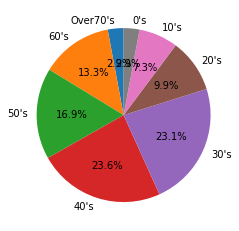

```
Over70's     32
60's        145
50's        184
40's        256
30's        251
20's        108
10's         79
0's          32
Name: age, dtype: int64
```

```python
age_counts = \
    df_customer_attribute_ai5["age"].value_counts().sort_index(ascending=False)
plt.pie(age_counts, labels=age_counts.index, autopct="%.1f%%", startangle=90)
plt.show()
print(age_counts)
```

### 【解説1】

- 性別に関する円グラフを5個（5エリア分）、年代に関する円グラフを5個（5エリア分）、合計で10この円グラフを表示してみました。
- これを見比べると、エリアによって性別・年代が変わることが分かるでしょう。どうやら同じ飲料でもサブカテゴリ（水・お茶・炭酸飲料・果汁飲料・コーヒー飲料…など）によって立寄者の性別・年代が変わるということが分かりました。
- ところで、このプログラムは以下の点で改善点があります。
  - まったく同じようなプログラムが複数ある
  - わざわざ画面をスクロールしないと比較ができない
- このような場合は、棒グラフにしてエリアごとに横に並べると良さそうです。（通常の）積み上げ棒グラフの場合と100%積み上げ棒グラフの場合を両方作成してみましょう。

### 【解答例2】

#### エリアごとの性別の棒グラフ（積み上げ）

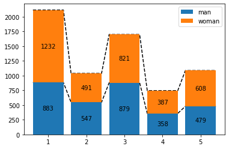

```python
# エリア×性別でクロス集計
tmp = df_customer_attribute.pivot_table(index="gender",columns="area_id",values="customer_id",aggfunc=len)
for i in range(len(tmp)):
    # 棒グラフの作成
    p = plt.bar(tmp.columns,tmp.iloc[i],bottom=tmp.iloc[:i].sum(),label=tmp.index[i])
    # データラベルの入力
    plt.bar_label(p,label_type="center")
    # 推移線の作成
    N = len(tmp.columns)
    ind = np.arange(N)
    width = 0.8   # 一つの棒グラフの太さ
    ind_p = ind + width/2
    ind_m = ind - width/2
    ind_line = np.sort(np.concatenate([ind_p,ind_m]))
    line = (np.insert(tmp.iloc[:i+1].sum().values,np.arange(N),tmp.iloc[:i+1].sum().values))
    plt.plot(ind_line,line,"--k",zorder=0)

plt.legend()
plt.show()
```

#### エリアごとの年代の棒グラフ（積み上げ）

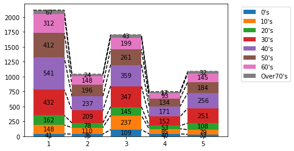

```python
# エリア×年齢でクロス集計
tmp = df_customer_attribute.pivot_table(index="age",columns="area_id",values="customer_id",aggfunc=len)
for i in range(len(tmp)):
    # 棒グラフの作成
    p = plt.bar(tmp.columns,tmp.iloc[i],bottom=tmp.iloc[:i].sum(),label=tmp.index[i])
    # データラベルの入力
    plt.bar_label(p,label_type="center")
    # 推移線の作成
    N = len(tmp.columns)
    ind = np.arange(N)
    width = 0.8   # 一つの棒グラフの太さ
    ind_p = ind + width/2
    ind_m = ind - width/2
    ind_line = np.sort(np.concatenate([ind_p,ind_m]))
    line = (np.insert(tmp.iloc[:i+1].sum().values,np.arange(N),tmp.iloc[:i+1].sum().values))
    plt.plot(ind_line,line,"--k",zorder=0)

# 凡例がグラフと重なるため、右上に
plt.legend(bbox_to_anchor=(1.05, 1),loc="upper left")
plt.show()
```

### 【解答例3】

#### エリアごとの性別の棒グラフ（100%積み上げ）

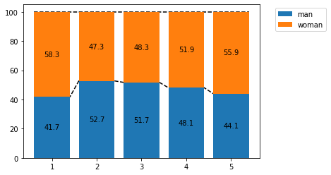

```python
# エリア×性別でクロス集計し、比率で返す
tmp = df_customer_attribute.pivot_table(index="gender",columns="area_id",values="customer_id",aggfunc=len).apply(lambda x : 100*x/sum(x), axis=0)
for i in range(len(tmp)):
    # 棒グラフの作成
    p = plt.bar(tmp.columns,tmp.iloc[i],bottom=tmp.iloc[:i].sum(),label=tmp.index[i])
    # データラベルの入力
    plt.bar_label(p,fmt="%.1f",label_type="center")
    # 推移線の作成
    N = len(tmp.columns)
    ind = np.arange(N)
    width = 0.8   # 一つの棒グラフの太さ
    ind_p = ind + width/2
    ind_m = ind - width/2
    ind_line = np.sort(np.concatenate([ind_p,ind_m]))
    line = (np.insert(tmp.iloc[:i+1].sum().values,np.arange(N),tmp.iloc[:i+1].sum().values))
    plt.plot(ind_line,line,"--k",zorder=0)

# 凡例がグラフと重なるため、右上に
plt.legend(bbox_to_anchor=(1.05, 1),loc="upper left")
plt.show()
```

#### エリアごとの年代の棒グラフ（100%積み上げ）

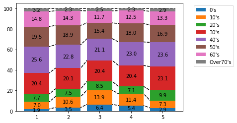

```python
# エリア×年齢でクロス集計し、比率で返す
tmp = df_customer_attribute.pivot_table(index="age",columns="area_id",values="customer_id",aggfunc=len).apply(lambda x : 100*x/sum(x), axis=0)
for i in range(len(tmp)):
    # 棒グラフの作成
    p = plt.bar(tmp.columns,tmp.iloc[i],bottom=tmp.iloc[:i].sum(),label=tmp.index[i])
    # データラベルの入力
    plt.bar_label(p,fmt="%.1f",label_type="center")
    # 推移線の作成
    N = len(tmp.columns)
    ind = np.arange(N)
    width = 0.8   # 一つの棒グラフの太さ
    ind_p = ind + width/2
    ind_m = ind - width/2
    ind_line = np.sort(np.concatenate([ind_p,ind_m]))
    line = (np.insert(tmp.iloc[:i+1].sum().values,np.arange(N),tmp.iloc[:i+1].sum().values))
    plt.plot(ind_line,line,"--k",zorder=0)

# 凡例がグラフと重なるため、右上に
plt.legend(bbox_to_anchor=(1.05, 1),loc="upper left")
plt.show()
```

### 【解説3】

- 100%積み上げグラフにすることで、エリアごとに構成比が比較しやすくなったのが分かるかと思います。
- このように、知りたいことを知るためにどのようなグラフで表現すると最も分かりやすいかを常に考えましょう。

## 5.2 性別の円グラフを作成する際に、男性と女性が分かりやすい色分けにしてみよう。

### 【解答例】

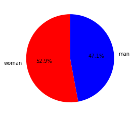

```
woman    3539
man      3146
Name: gender, dtype: int64
```

```python
gender_counts = df_customer_attribute["gender"].value_counts()
pie_colors = ["r", "b"]
plt.pie(\
    gender_counts, labels=gender_counts.index, autopct="%.1f%%", startangle=90, colors=pie_colors)
plt.show()
print(gender_counts)
```

### 【解説】

- 2行目で円グラフの色を指定しています。rはred（赤）、bはblue（青）を意味しています。
- これを3行目でパラメタとして指定しています。これで色を変更できます。

## 5.3 滞在時間と商品接触回数に相関はあるだろうか？また、他にも相関がありそうな変数はあるだろうか？調べてみよう。

### 【解答例】

```python
shopper_time_duration_list = df_et1[["customer_id","time_duration"]].set_index("customer_id")
shopper_time_duration_list
```

| customer_id | time_duration |
| --- | --- |
| 20201026-010001 | 6.2 |
| 20201026-010003 | 14.2 |
| 20201026-010004 | 21.0 |
| 20201026-010005 | 19.2 |
| 20201026-010006 | 19.8 |
| ... | ... |
| 20201101-120046 | 13.6 |
| 20201101-120047 | 4.6 |
| 20201101-120049 | 11.2 |
| 20201101-120052 | 28.6 |
| 20201101-120057 | 13.8 |

9116 rows × 1 columns

```python
shopper_contact_list = df.groupby("customer_id")[["num_touch"]].sum().astype(int).rename(columns={"num_touch" : "接触回数"})
shopper_contact_list
```

| customer_id | 接触回数 |
| --- | --- |
| 20201026-010001 | 2 |
| 20201026-010003 | 3 |
| 20201026-010004 | 0 |
| 20201026-010005 | 1 |
| 20201026-010006 | 2 |
| ... | ... |
| 20201101-120046 | 0 |
| 20201101-120047 | 1 |
| 20201101-120049 | 1 |
| 20201101-120052 | 4 |
| 20201101-120057 | 0 |

9116 rows × 1 columns

```python
df_shopper = pd.concat([shopper_time_duration_list, shopper_contact_list], axis=1)
df_shopper
```

| customer_id | time_duration | 接触回数 |
| --- | --- | --- |
| 20201026-010001 | 6.2 | 2 |
| 20201026-010003 | 14.2 | 3 |
| 20201026-010004 | 21.0 | 0 |
| 20201026-010005 | 19.2 | 1 |
| 20201026-010006 | 19.8 | 2 |
| ... | ... | ... |
| 20201101-120046 | 13.6 | 0 |
| 20201101-120047 | 4.6 | 1 |
| 20201101-120049 | 11.2 | 1 |
| 20201101-120052 | 28.6 | 4 |
| 20201101-120057 | 13.8 | 0 |

9116 rows × 2 columns

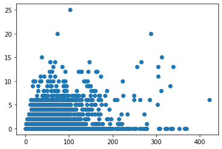

```python
plt.scatter(df_shopper["time_duration"], df_shopper["接触回数"])
```

```python
df_shopper.corr()
```

|  | time_duration | 接触回数 |
| --- | --- | --- |
| time_duration | 1.000000 | 0.291069 |
| 接触回数 | 0.291069 | 1.000000 |

### 【解説】

- 最初に人物IDと滞在時間のDataFrameを、次に人物IDと商品接触回数のDataFrameをそれぞれ作成し、マージしてひとつのDataFrameとしました。
- その後に散布図を作成して相関係数を算出しました。散布図からもだいたい分かりますが、相関係数も0.3を下回っており、あまり相関が無さそうなことが分かりました。
- 同じような方法で、他にも「購入回数」や「立寄時間帯」などで相関を確認してみると、なにか発見があるかもしれません。